# Segundo_Punto_Correción

Angie Lorena Pradilla

30/12/2020

La idea principal del modelo es predecir el rendimiento rendimiento del combustible en realción a los pasajeros para esto fue necesario dividir los kilómetros recorridos por los galones de combustible.

```r
library(PerformanceAnalytics)
library(readr)
library(dplyr)
```

```r
library(ggplot2)
data_modelo <- read_csv("C:/Users/User/Desktop/20201124-test-convocatoria/02. modelacion_datos/data_modelo1.csv")
datos <- data_modelo
data_modelo$rendimiento <- datos$KmT/datos$Gal
```

# Tipologia T1

Vamos a tomar la primera tipología para llevar a cabo el modelo y su análisis

```r
test1 <- data_modelo %>%
  mutate(Fecha = lubridate::ymd(Fecha)) %>%
  filter(tipologia == "T1") %>%
  select(Fecha, Pas, rendimiento)
```

Antes de llevar a cabo el modelo es importante verificar la correlación entre variables para tener una idea tienen algun indicio de relación ya sea positiva o negativa, para ello visualizamos dicha correlación, gráfico de dispersión y densidades de la siguiente manera:

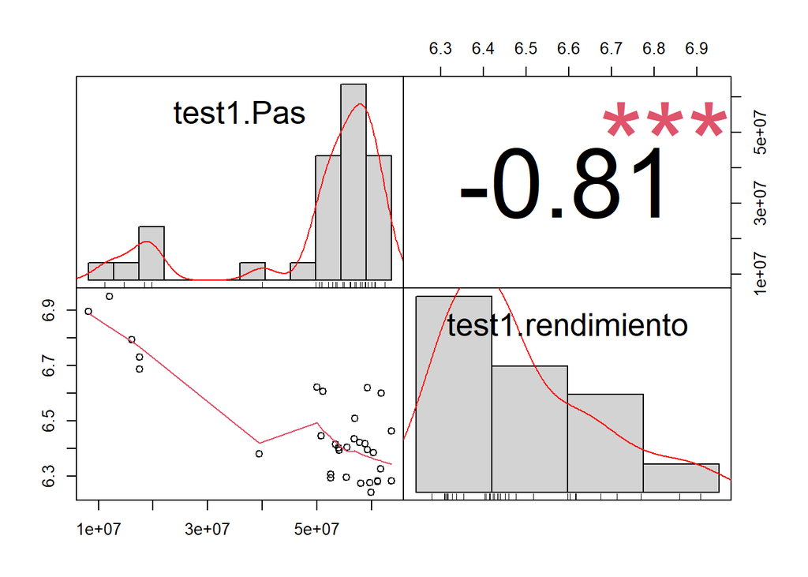

```r
dat1 <- data.frame(test1$Pas, test1$rendimiento)
chart.Correlation(dat1)
```

De acuerdo con el gráfico anterior es posible decir que existe una fuerte correlación inversa entre la variable pasajeros y el rendmiento del combustible y tiene sentido pues al transportar menos pasajeros el vehículo hace un menor esfuerzo y por ende el rendimiento de combustible por cada kilometro es mayor.

De esta manera realizamos el modelo de regresión simple en donde la variable dependiente es el rendmiento que dependerá del número de pasajeros.

```r
modelo1 <- lm(rendimiento ~ Pas, test1)
summary(modelo1)
```

```
##
## Call:
## lm(formula = rendimiento ~ Pas, data = test1)
##
## Residuals:
##      Min       1Q   Median       3Q      Max
## -0.18106 -0.07978 -0.01453  0.03706  0.24612
##
## Coefficients:
##               Estimate Std. Error t value Pr(>|t|)
## (Intercept)  6.932e+00  6.393e-02 108.428  < 2e-16 ***
## Pas         -9.369e-09  1.218e-09  -7.693 1.39e-08 ***
## ---
## Signif. codes:  0 '***' 0.001 '**' 0.01 '*' 0.05 '.' 0.1 ' ' 1
##
## Residual standard error: 0.1111 on 30 degrees of freedom
## Multiple R-squared:  0.6636, Adjusted R-squared:  0.6524
## F-statistic: 59.19 on 1 and 30 DF,  p-value: 1.395e-08
```

A continuación la gráfica del modelo:

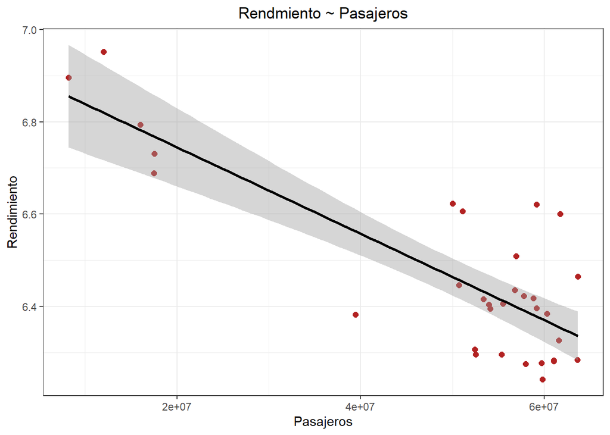

```r
ggplot(data = test1, mapping = aes(x = Pas, y = rendimiento)) +
  geom_point(color = "firebrick", size = 2) +
  geom_smooth(method = "lm", se = TRUE, color = "black") +
  labs(title = "Rendmiento ~ Pasajeros", x = "Pasajeros", y = "Rendimiento") +
  theme_bw() + theme(plot.title = element_text(hjust = 0.5))
```

Antes de realizar algún tipo de predicción es necesario llevar a cabo los supuestos del modelo

## Independecia de residuales

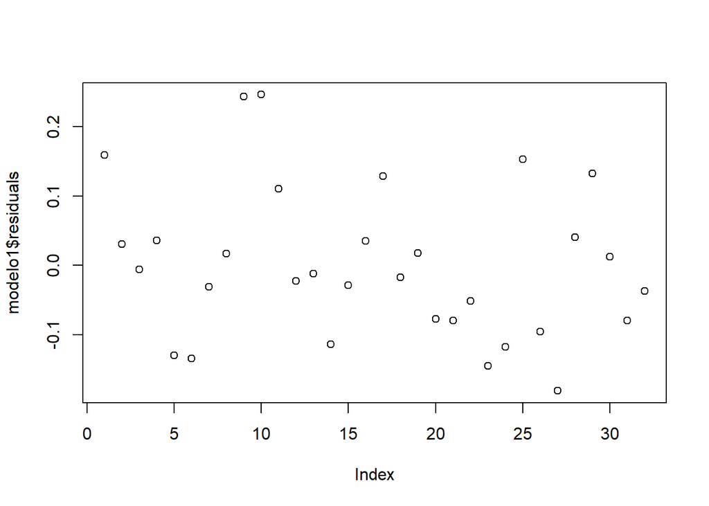

```r
plot(modelo1$residuals)
```

No se observa un patrón definido para los residuos, quiere decir que al no seguir una tendencia clara es posible decir que los residuos son independientes, sin embargo observaremos los residuos estandarizados

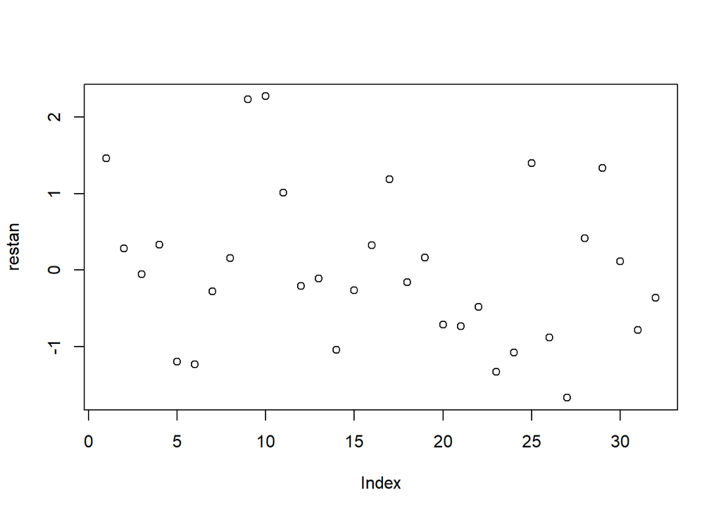

```r
restan<-rstandard(modelo1)
  plot(restan)
```

Se confirma que no hay un patrón definido ni una tendencia de los residuos, ademas estos se mueven entre el invervalo aproximado de -2 y 2 y no se evidencian datos atípicos.

## Normalidad de los residuos

En este caso la hipótesis nula es Ho= Los residuales tienen distribución normal vs H1= Los residuos no tienen distribución normal, en este caso nuestro objetivo sería no rechazar la nula

```r
shapiro.test(modelo1$residuals)
```

```
##
##  Shapiro-Wilk normality test
##
## data:  modelo1$residuals
## W = 0.95322, p-value = 0.1778
```

El modelo cumple con el supuesto de normalidad dado a que el p valor es mayor al nivel de significancia del 5%

## Homoscedasticidad de los residuos con el test Breush- Pagan

```r
library(lmtest)
bptest(modelo1)
```

```
##
##  studentized Breusch-Pagan test
##
## data:  modelo1
## BP = 0.52861, df = 1, p-value = 0.4672
```

Dado lo anterior, se puede decir que los residuales tienen varianza constante debido a que no rechazamos la hipotesis nula dado a que el p valor es mayor al nivel de significancia del 5%. **De acuerdo a esto el modelo cumpliría con las condiciones para aceptar el modelo**

# Tipología t2

```r
test2 <- data_modelo %>%
  mutate(Fecha = lubridate::ymd(Fecha)) %>%
  filter(tipologia == "T2") %>%
  select(Fecha, Pas, rendimiento)
```

Antes de llevar a cabo el modelo es importante verificar la correlación entre variables para tener una idea tienen algun indicio de relación ya sea positiva o negativa, para ello visualizamos dicha correlación, gráfico de dispersión y densidades de la siguiente manera:

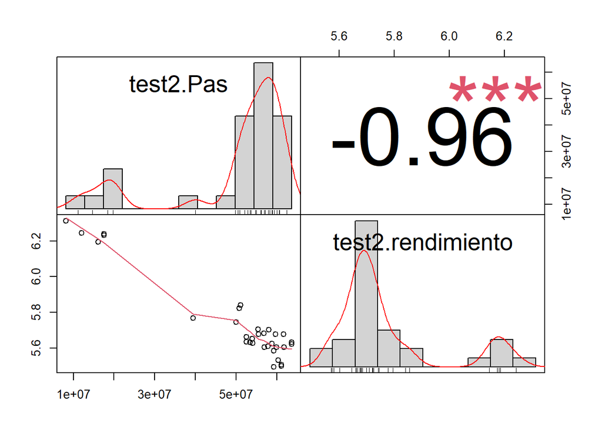

```r
dat2 <- data.frame(test2$Pas, test2$rendimiento)
chart.Correlation(dat2)
```

De acuerdo con el gráfico anterior es posible decir que existe una fuerte correlación inversa entre la variable pasajeros y el rendmiento del combustible y tiene sentido pues al transportar menos pasajeros el vehículo hace un menor esfuerzo y por ende el rendimiento de combustible por cada kilometro es mayor.

De esta manera realizamos el modelo de regresión simple en donde la variable dependiente es el rendmiento que dependerá del número de pasajeros.

```r
modelo2 <- lm(rendimiento ~ Pas, test2)
summary(modelo2)
```

```
##
## Call:
## lm(formula = rendimiento ~ Pas, data = test2)
##
## Residuals:
##      Min       1Q   Median       3Q      Max
## -0.11739 -0.04494 -0.00007  0.04568  0.11825
##
## Coefficients:
##               Estimate Std. Error t value Pr(>|t|)
## (Intercept)  6.428e+00  3.747e-02  171.57   <2e-16 ***
## Pas         -1.380e-08  7.137e-10  -19.34   <2e-16 ***
## ---
## Signif. codes:  0 '***' 0.001 '**' 0.01 '*' 0.05 '.' 0.1 ' ' 1
##
## Residual standard error: 0.06513 on 30 degrees of freedom
## Multiple R-squared:  0.9257, Adjusted R-squared:  0.9233
## F-statistic: 373.9 on 1 and 30 DF,  p-value: < 2.2e-16
```

A continuación la gráfica del modelo:

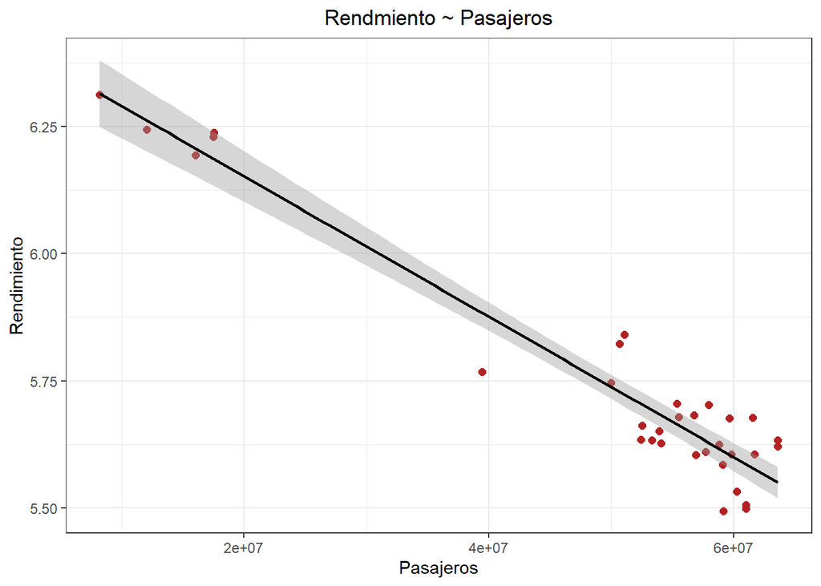

```r
ggplot(data = test2, mapping = aes(x = Pas, y = rendimiento)) +
  geom_point(color = "firebrick", size = 2) +
  geom_smooth(method = "lm", se = TRUE, color = "black") +
  labs(title = "Rendmiento ~ Pasajeros", x = "Pasajeros", y = "Rendimiento") +
  theme_bw() + theme(plot.title = element_text(hjust = 0.5))
```

Antes de realizar algún tipo de predicción es necesario llevar a cabo los supuestos del modelo

## Independecia de residuales

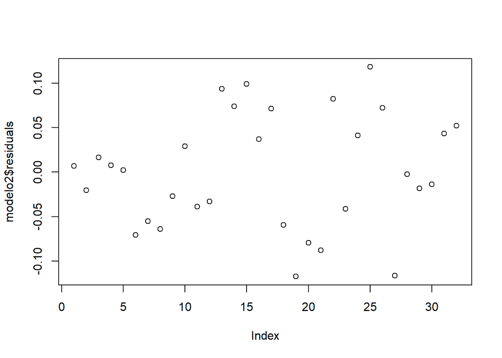

```r
plot(modelo2$residuals)
```

No se observa un patrón definido para los residuos, quiere decir que al no seguir una tendencia clara es posible decir que los residuos son independientes, sin embargo observaremos los residuos estandarizados

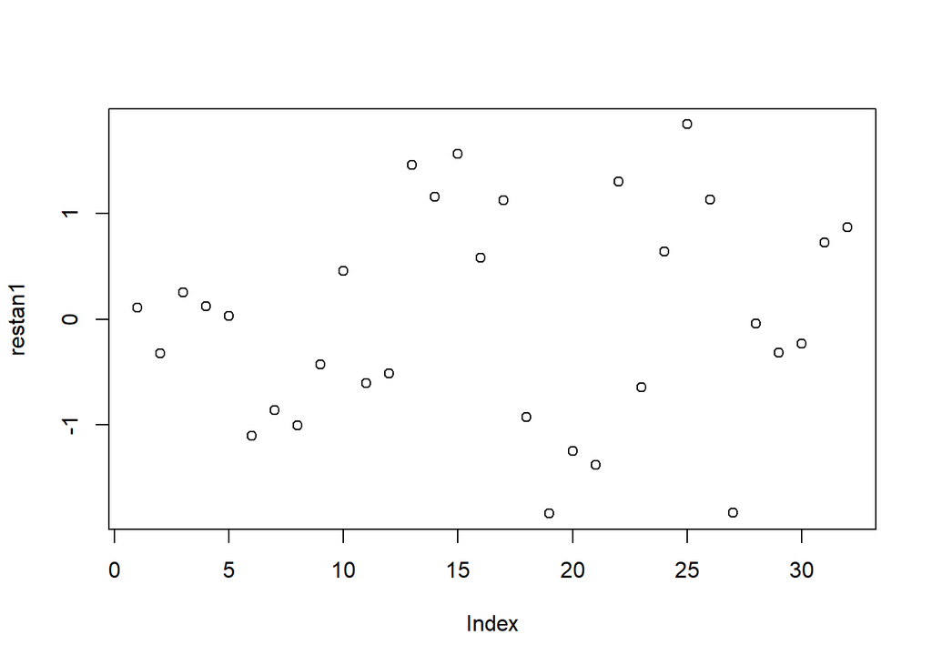

```r
restan1<-rstandard(modelo2)
  plot(restan1)
```

Se confirma que no hay un patrón definido ni una tendencia de los residuos, ademas estos se mueven entre el invervalo aproximado de -2 y 2 y no se evidencian datos atípicos.

## Normalidad de los residuos

En este caso la hipótesis nula es Ho= Los residuales tienen distribución normal vs H1= Los residuos no tienen distribución normal, en este caso nuestro objetivo sería no rechazar la nula

```r
shapiro.test(modelo2$residuals)
```

```
##
##  Shapiro-Wilk normality test
##
## data:  modelo2$residuals
## W = 0.97725, p-value = 0.7166
```

El modelo cumple con el supuesto de normalidad dado a que el p valor es mayor al nivel de significancia del 5%

## Homoscedasticidad de los residuos con el test Breush- Pagan

```r
library(lmtest)
bptest(modelo2)
```

```
##
##  studentized Breusch-Pagan test
##
## data:  modelo2
## BP = 1.7579, df = 1, p-value = 0.1849
```

Dado lo anterior, se puede decir que los residuales tienen varianza constante debido a que no rechazamos la hipotesis nula dado a que el p valor es mayor al nivel de significancia del 5%. **De acuerdo a esto el modelo cumpliría con las condiciones para aceptar el modelo**

# Tipología T3

```r
test3 <- data_modelo %>%
  mutate(Fecha = lubridate::ymd(Fecha)) %>%
  filter(tipologia == "T3") %>%
  select(Fecha, Pas, rendimiento)
```

Antes de llevar a cabo el modelo es importante verificar la correlación entre variables para tener una idea tienen algun indicio de relación ya sea positiva o negativa, para ello visualizamos dicha correlación, gráfico de dispersión y densidades de la siguiente manera:

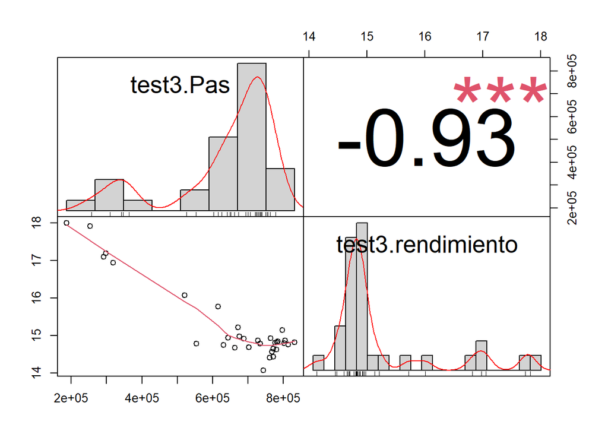

```r
dat3 <- data.frame(test3$Pas, test3$rendimiento)
chart.Correlation(dat3)
```

De acuerdo con el gráfico anterior es posible decir que existe una fuerte correlación inversa entre la variable pasajeros y el rendmiento del combustible y tiene sentido pues al transportar menos pasajeros el vehículo hace un menor esfuerzo y por ende el rendimiento de combustible por cada kilometro es mayor.

De esta manera realizamos el modelo de regresión simple en donde la variable dependiente es el rendmiento que dependerá del número de pasajeros.

```r
modelo3 <- lm(rendimiento ~ Pas, test3)
summary(modelo3)
```

```
##
## Call:
## lm(formula = rendimiento ~ Pas, data = test3)
##
## Residuals:
##      Min       1Q   Median       3Q      Max
## -0.98447 -0.18305  0.01825  0.28097  0.63302
##
## Coefficients:
##               Estimate Std. Error t value Pr(>|t|)
## (Intercept)  1.865e+01  2.521e-01   73.95  < 2e-16 ***
## Pas         -5.187e-06  3.712e-07  -13.97 1.14e-14 ***
## ---
## Signif. codes:  0 '***' 0.001 '**' 0.01 '*' 0.05 '.' 0.1 ' ' 1
##
## Residual standard error: 0.3818 on 30 degrees of freedom
## Multiple R-squared:  0.8668, Adjusted R-squared:  0.8624
## F-statistic: 195.3 on 1 and 30 DF,  p-value: 1.135e-14
```

A continuación la gráfica del modelo:

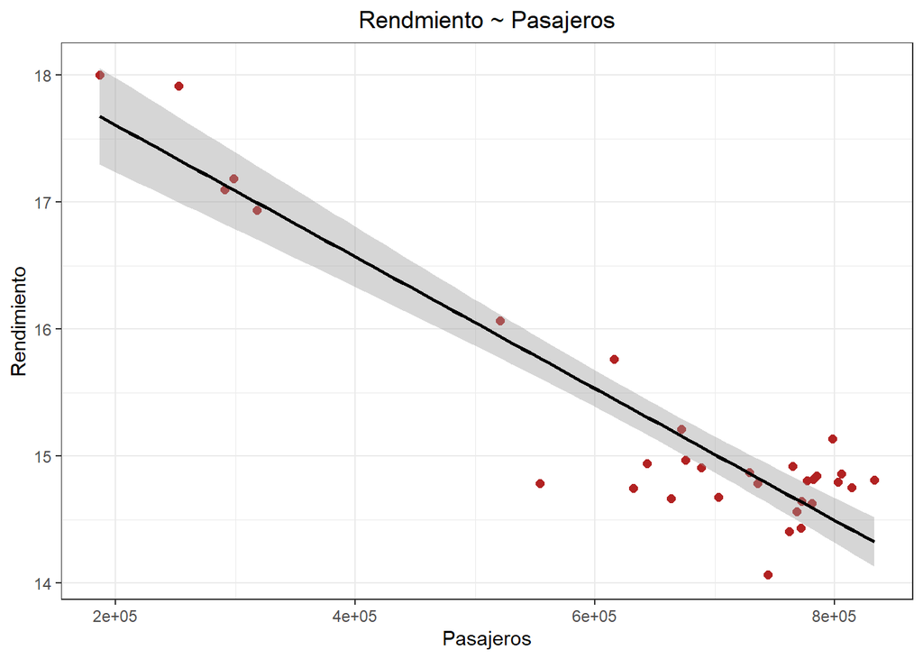

```r
ggplot(data = test3, mapping = aes(x = Pas, y = rendimiento)) +
  geom_point(color = "firebrick", size = 2) +
  geom_smooth(method = "lm", se = TRUE, color = "black") +
  labs(title = "Rendmiento ~ Pasajeros", x = "Pasajeros", y = "Rendimiento") +
  theme_bw() + theme(plot.title = element_text(hjust = 0.5))
```

Antes de realizar algún tipo de predicción es necesario llevar a cabo los supuestos del modelo

## Independecia de residuales

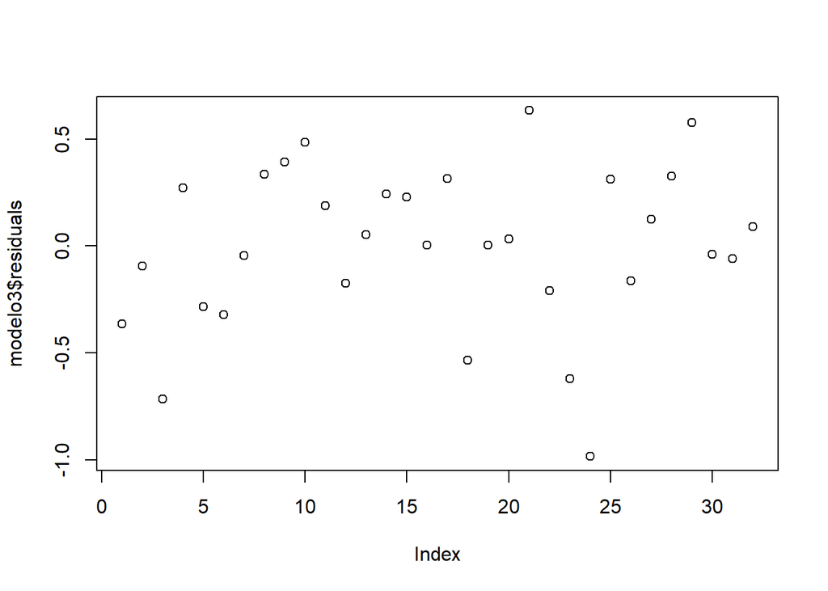

```r
plot(modelo3$residuals)
```

No se observa un patrón definido para los residuos, quiere decir que al no seguir una tendencia clara es posible decir que los residuos son independientes, sin embargo observaremos los residuos estandarizados

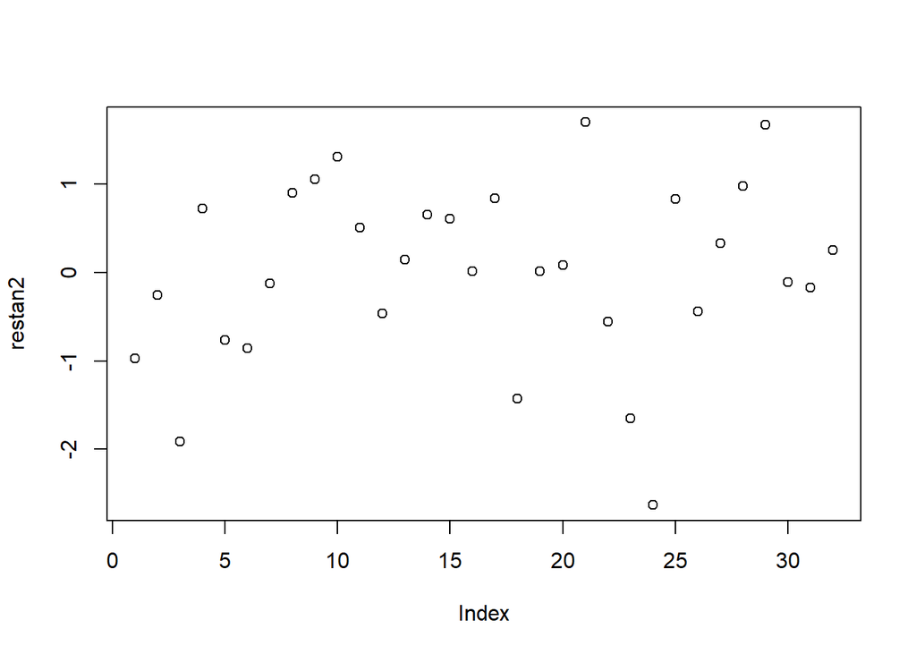

```r
restan2<-rstandard(modelo3)
  plot(restan2)
```

## Normalidad de los residuos

En este caso la hipótesis nula es Ho= Los residuales tienen distribución normal vs H1= Los residuos no tienen distribución normal, en este caso nuestro objetivo sería no rechazar la nula

```r
shapiro.test(modelo3$residuals)
```

```
##
##  Shapiro-Wilk normality test
##
## data:  modelo3$residuals
## W = 0.96728, p-value = 0.428
```

El modelo cumple con el supuesto de normalidad dado a que el p valor es mayor al nivel de significancia del 5%

## Homoscedasticidad de los residuos con el test Breush- Pagan

```r
library(lmtest)
bptest(modelo3)
```

```
##
##  studentized Breusch-Pagan test
##
## data:  modelo3
## BP = 0.055628, df = 1, p-value = 0.8135
```

Dado lo anterior, se puede decir que los residuales tienen varianza constante debido a que no rechazamos la hipotesis nula dado a que el p valor es mayor al nivel de significancia del 5%. **De acuerdo a esto el modelo cumpliría con las condiciones para aceptar el modelo**

#Tipología T4

```r
test4 <- data_modelo %>%
  mutate(Fecha = lubridate::ymd(Fecha)) %>%
  filter(tipologia == "T4") %>%
  select(Fecha, Pas, rendimiento)
```

Antes de llevar a cabo el modelo es importante verificar la correlación entre variables para tener una idea tienen algun indicio de relación ya sea positiva o negativa, para ello visualizamos dicha correlación, gráfico de dispersión y densidades de la siguiente manera:

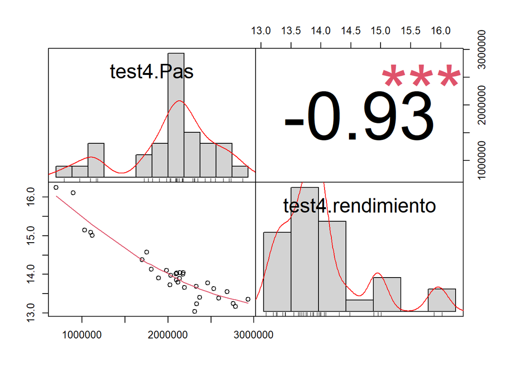

```r
dat4 <- data.frame(test4$Pas, test4$rendimiento)
chart.Correlation(dat4)
```

De acuerdo con el gráfico anterior es posible decir que existe una fuerte correlación inversa entre la variable pasajeros y el rendmiento del combustible y tiene sentido pues al transportar menos pasajeros el vehículo hace un menor esfuerzo y por ende el rendimiento de combustible por cada kilometro es mayor.

De esta manera realizamos el modelo de regresión simple en donde la variable dependiente es el rendmiento que dependerá del número de pasajeros.

```r
modelo4 <- lm(rendimiento ~ Pas, test4)
summary(modelo4)
```

```
##
## Call:
## lm(formula = rendimiento ~ Pas, data = test4)
##
## Residuals:
##      Min       1Q   Median       3Q      Max
## -0.65406 -0.18843  0.00545  0.14341  0.59327
##
## Coefficients:
##               Estimate Std. Error t value Pr(>|t|)
## (Intercept)  1.666e+01  1.882e-01   88.52  < 2e-16 ***
## Pas         -1.284e-06  8.902e-08  -14.42 4.97e-15 ***
## ---
## Signif. codes:  0 '***' 0.001 '**' 0.01 '*' 0.05 '.' 0.1 ' ' 1
##
## Residual standard error: 0.2759 on 30 degrees of freedom
## Multiple R-squared:  0.8739, Adjusted R-squared:  0.8697
## F-statistic:   208 on 1 and 30 DF,  p-value: 4.973e-15
```

A continuación la gráfica del modelo:

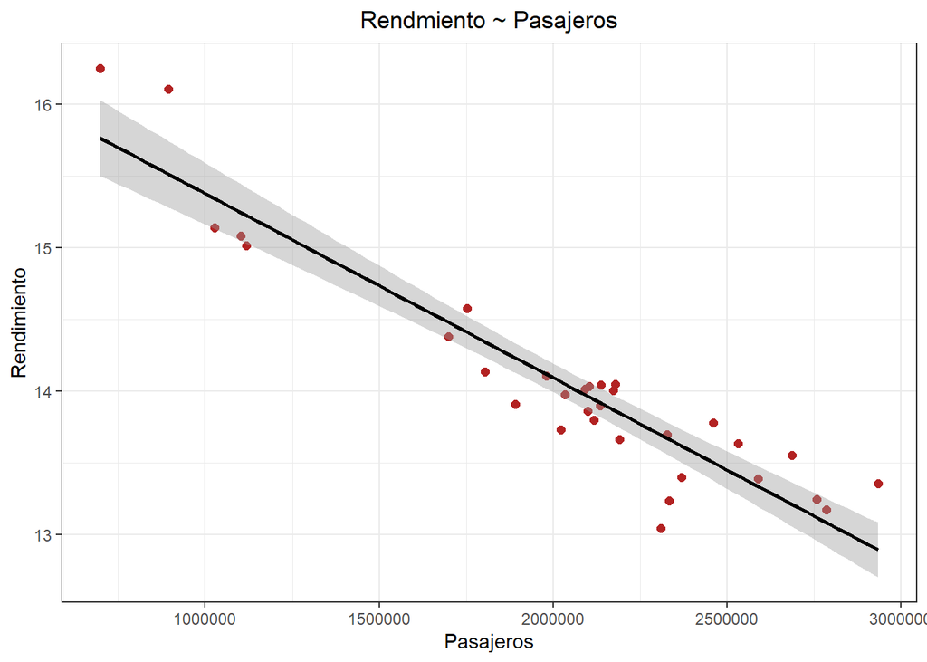

```r
ggplot(data = test4, mapping = aes(x = Pas, y = rendimiento)) +
  geom_point(color = "firebrick", size = 2) +
  geom_smooth(method = "lm", se = TRUE, color = "black") +
  labs(title = "Rendmiento ~ Pasajeros", x = "Pasajeros", y = "Rendimiento") +
  theme_bw() + theme(plot.title = element_text(hjust = 0.5))
```

Antes de realizar algún tipo de predicción es necesario llevar a cabo los supuestos del modelo

## Independecia de residuales

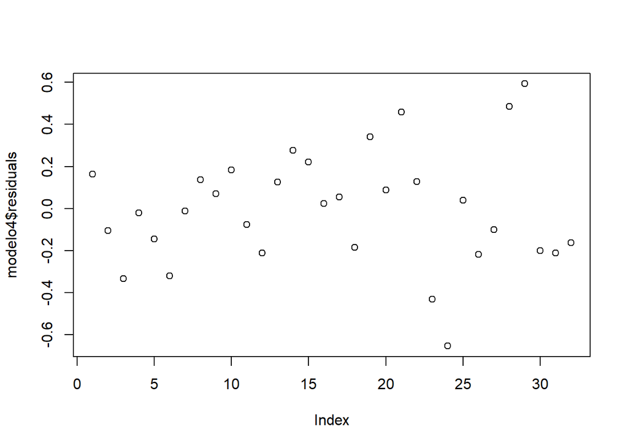

```r
plot(modelo4$residuals)
```

No se observa un patrón definido para los residuos, quiere decir que al no seguir una tendencia clara es posible decir que los residuos son independientes, sin embargo observaremos los residuos estandarizados

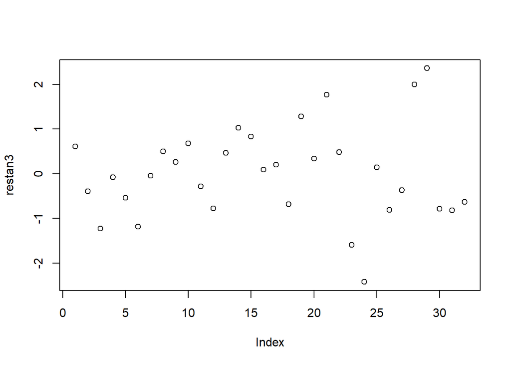

```r
restan3<-rstandard(modelo4)
  plot(restan3)
```

## Normalidad de los residuos

En este caso la hipótesis nula es Ho= Los residuales tienen distribución normal vs H1= Los residuos no tienen distribución normal, en este caso nuestro objetivo sería no rechazar la nula

```r
shapiro.test(modelo4$residuals)
```

```
##
##  Shapiro-Wilk normality test
##
## data:  modelo4$residuals
## W = 0.98826, p-value = 0.9742
```

El modelo cumple con el supuesto de normalidad dado a que el p valor es mayor al nivel de significancia del 5%

## Homoscedasticidad de los residuos con el test Breush- Pagan

```r
library(lmtest)
bptest(modelo4)
```

```
##
##  studentized Breusch-Pagan test
##
## data:  modelo4
## BP = 1.0786, df = 1, p-value = 0.299
```

Dado lo anterior, se puede decir que los residuales tienen varianza constante debido a que no rechazamos la hipotesis nula dado a que el p valor es mayor al nivel de significancia del 5%. **De acuerdo a esto el modelo cumpliría con las condiciones para aceptar el modelo**

# Tipología T5

```r
test5 <- data_modelo %>%
  mutate(Fecha = lubridate::ymd(Fecha)) %>%
  filter(tipologia == "T5") %>%
  select(Fecha, Pas, rendimiento)
```

Antes de llevar a cabo el modelo es importante verificar la correlación entre variables para tener una idea tienen algun indicio de relación ya sea positiva o negativa, para ello visualizamos dicha correlación, gráfico de dispersión y densidades de la siguiente manera:

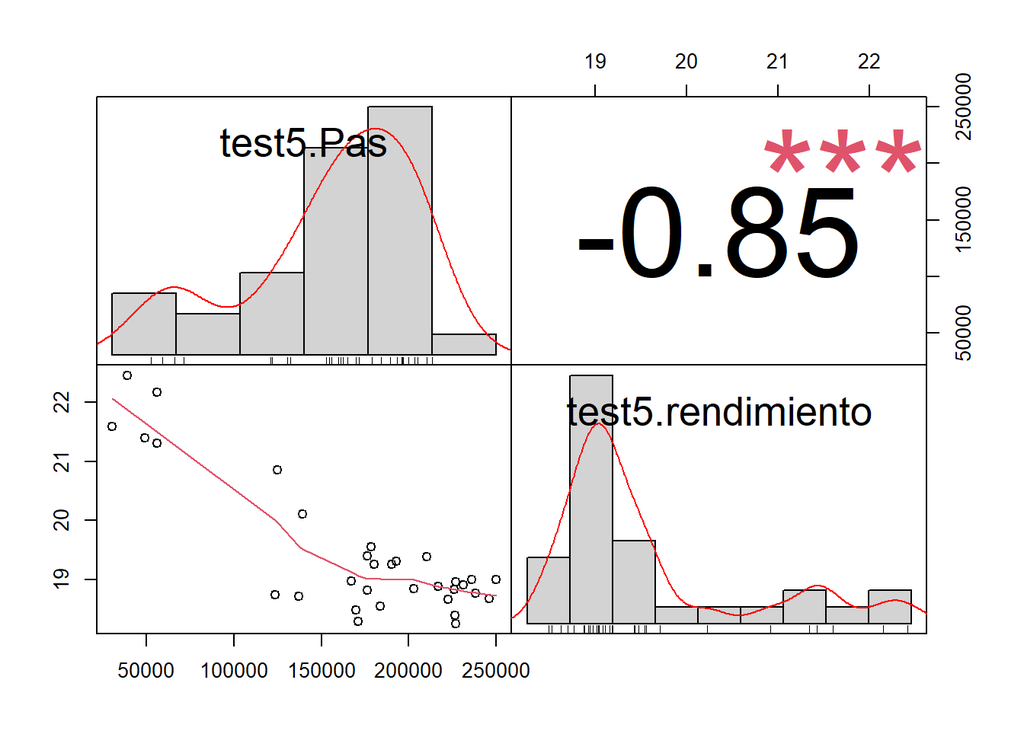

```r
dat5 <- data.frame(test5$Pas, test5$rendimiento)
chart.Correlation(dat5)
```

De acuerdo con el gráfico anterior es posible decir que existe una fuerte correlación inversa entre la variable pasajeros y el rendmiento del combustible y tiene sentido pues al transportar menos pasajeros el vehículo hace un menor esfuerzo y por ende el rendimiento de combustible por cada kilometro es mayor.

De esta manera realizamos el modelo de regresión simple en donde la variable dependiente es el rendmiento que dependerá del número de pasajeros.

```r
modelo5 <- lm(rendimiento ~ Pas, test5)
summary(modelo5)
```

```
##
## Call:
## lm(formula = rendimiento ~ Pas, data = test5)
##
## Residuals:
##     Min      1Q  Median      3Q     Max
## -1.4306 -0.2374  0.1043  0.3707  1.0071
##
## Coefficients:
##               Estimate Std. Error t value Pr(>|t|)
## (Intercept)  2.205e+01  3.149e-01  70.028  < 2e-16 ***
## Pas         -1.523e-05  1.717e-06  -8.872 6.87e-10 ***
## ---
## Signif. codes:  0 '***' 0.001 '**' 0.01 '*' 0.05 '.' 0.1 ' ' 1
##
## Residual standard error: 0.6193 on 30 degrees of freedom
## Multiple R-squared:  0.7241, Adjusted R-squared:  0.7149
## F-statistic: 78.72 on 1 and 30 DF,  p-value: 6.874e-10
```

A continuación la gráfica del modelo:

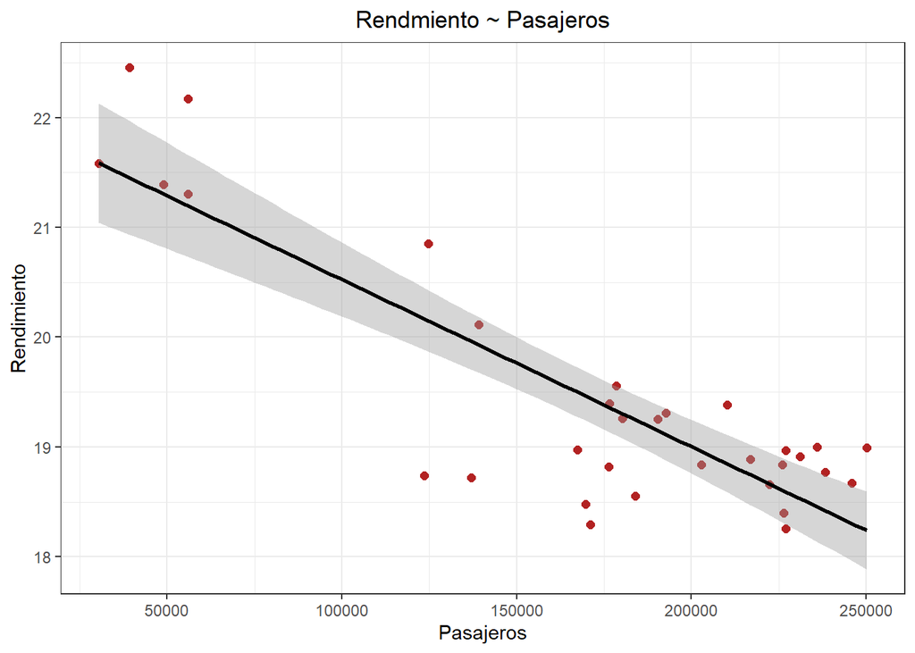

```r
ggplot(data = test5, mapping = aes(x = Pas, y = rendimiento)) +
  geom_point(color = "firebrick", size = 2) +
  geom_smooth(method = "lm", se = TRUE, color = "black") +
  labs(title = "Rendmiento ~ Pasajeros", x = "Pasajeros", y = "Rendimiento") +
  theme_bw() + theme(plot.title = element_text(hjust = 0.5))
```

Antes de realizar algún tipo de predicción es necesario llevar a cabo los supuestos del modelo

## Independecia de residuales

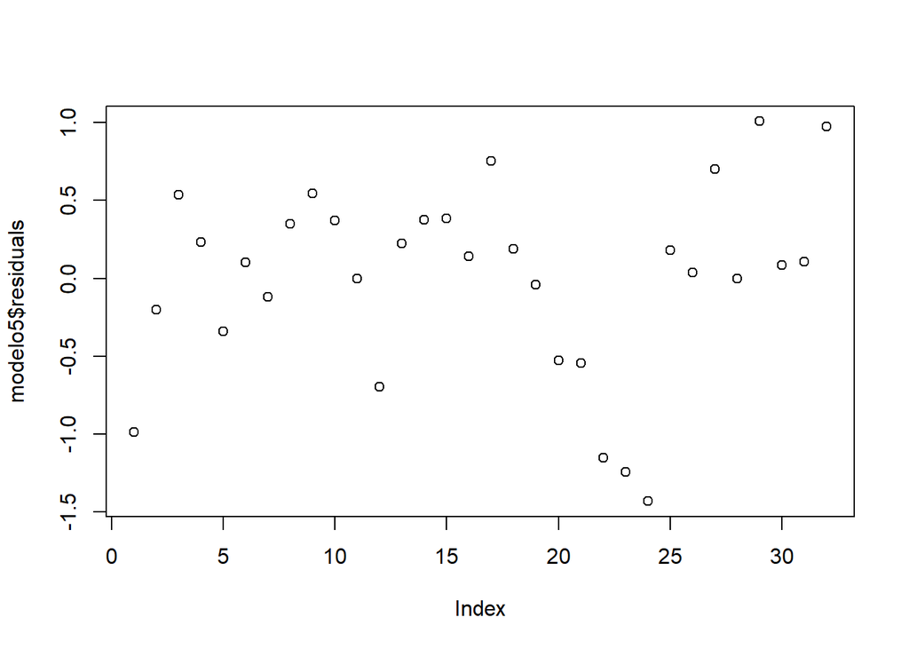

```r
plot(modelo5$residuals)
```

No se observa un patrón definido para los residuos, quiere decir que al no seguir una tendencia clara es posible decir que los residuos son independientes, sin embargo observaremos los residuos estandarizados

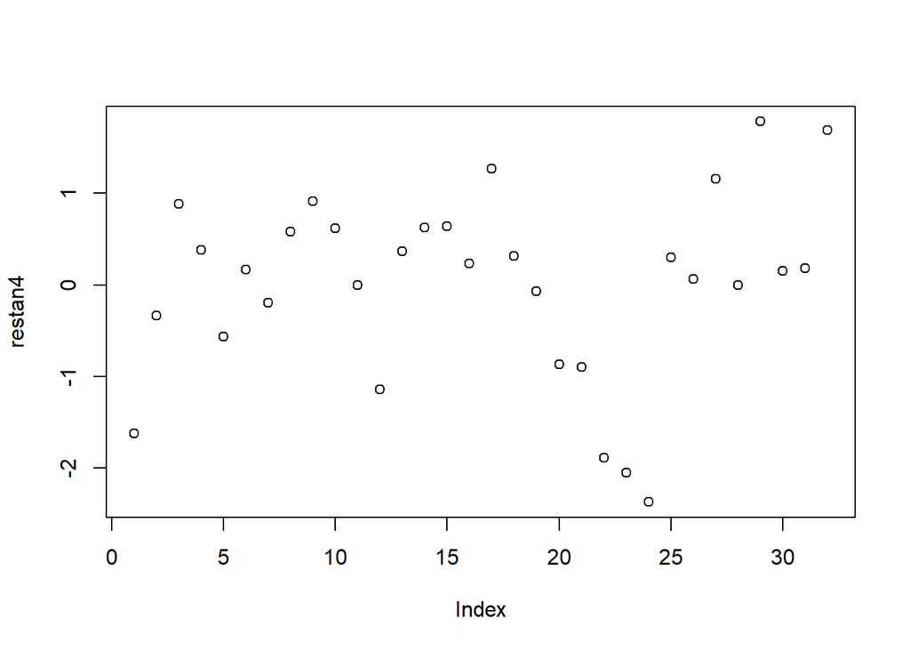

```r
restan4<-rstandard(modelo5)
  plot(restan4)
```

## Normalidad de los residuos

En este caso la hipótesis nula es Ho= Los residuales tienen distribución normal vs H1= Los residuos no tienen distribución normal, en este caso nuestro objetivo sería no rechazar la nula

```r
shapiro.test(modelo5$residuals)
```

```
##
##  Shapiro-Wilk normality test
##
## data:  modelo5$residuals
## W = 0.9411, p-value = 0.08047
```

El modelo cumple con el supuesto de normalidad dado a que el p valor es mayor al nivel de significancia del 5%

## Homoscedasticidad de los residuos con el test Breush- Pagan

```r
library(lmtest)
bptest(modelo5)
```

```
##
##  studentized Breusch-Pagan test
##
## data:  modelo5
## BP = 2.6367, df = 1, p-value = 0.1044
```

Dado lo anterior, se puede decir que los residuales tienen varianza constante debido a que no rechazamos la hipotesis nula dado a que el p valor es mayor al nivel de significancia del 5%. **De acuerdo a esto el modelo cumpliría con las condiciones para aceptar el modelo**

De acuerdo a lo anterior, las funciones y predicciones para los modelos de las 5 tipologías anteriores son:

### T1

$$Rendimiento\left(Pasajeros\right) = \ 6.93227 - 0.000000009369* Pasajeros$$
En este modelo, por cada unidad de pasajeros adicional, el rendimiento del combustible disminuye en 0.000000009369 unidades.

Con lo siguiente vamos a calcular el rendimiento esperado cuando hay 49989132 pasajeros:

```r
predict(modelo1, data.frame(Pas = 49989132), interval = "prediction")
```

```
##        fit      lwr      upr
## 1 6.463925 6.233437 6.694413
```

### T2

$$Rendimiento\left(Pasajeros\right) = \ 6.42825 - 0.0000000138007*Pasajeros$$
En este modelo, por cada unidad de pasajeros adicional, el rendimiento del combustible disminuye en 0.0000000138007 unidades.

Con lo siguiente vamos a calcular el rendimiento esperado cuando hay 49989132 pasajeros:

```r
predict(modelo2, data.frame(Pas = 49989132), interval = "prediction")
```

```
##        fit      lwr      upr
## 1 5.738371 5.603301 5.873441
```

### T3

$$Rendimiento\left(Pasajeros\right) = \ 18.6462359236 - 0.0000051874*Pasajeros$$
En este modelo, por cada unidad de pasajeros adicional, el rendimiento del combustible disminuye en 0.0000051874 unidades.

Con lo siguiente vamos a calcular el rendimiento esperado cuando hay 49989132 pasajeros:

```r
predict(modelo3, data.frame(Pas = 49989132), interval = "prediction")
```

```
##         fit       lwr       upr
## 1 -240.6695 -278.0806 -203.2584
```

### T4

$$Rendimiento\left(Pasajeros\right) = \ 16.65906147579 - 0.00000128371*Pasajeros$$
En este modelo, por cada unidad de pasajeros adicional, el rendimiento del combustible disminuye en 0.00000128371 unidades.

Con lo siguiente vamos a calcular el rendimiento esperado cuando hay 49989132 pasajeros:

```r
predict(modelo4, data.frame(Pas = 49989132), interval = "prediction")
```

```
##         fit       lwr       upr
## 1 -47.51263 -56.24833 -38.77693
```

### T5

$$Rendimiento\left(Pasajeros\right) = \ 22.0496 - 0.000015234*Pasajeros$$
En este modelo, por cada unidad de pasajeros adicional, el rendimiento del combustible disminuye en 0.000015234 unidades.

Con lo siguiente vamos a calcular el rendimiento esperado cuando hay 49989132 pasajeros:

```r
predict(modelo5, data.frame(Pas = 49989132), interval = "prediction")
```

```
##         fit       lwr       upr
## 1 -739.4628 -914.1545 -564.7712
```